# Filtering SMS Spam Using Naive Bayes

Jacer Sellami

10/01/2020

Note: Some part of the materials used in this text are borrowed from the book of Bret Lentz et al, “Machine Learning with R”, 2015. And others from R-pubs website.

# 1 Libraries

```r
#install.packages("quanteda")# Quantitative Analysis of Textual Data.
library(quanteda)
# install.packages("tm")
library(tm) #text mining package from R community, tm_map(), content_transformer()
```

```r
# install.packages("SnowballC")
library(SnowballC) #used for stemming, wordStem(), stemDocument()
# install.packages("wordcloud")
library(wordcloud) #wordcloud generator
# install.packages("e1071")
library(e1071) #Naive Bayes
# install.packages(gmodels)
library(gmodels) #CrossTable()
# install.packages("caret")
library(caret) #ConfusionMatrix()
```

# 2 Import data

```r
sms_raw <- read.table("SMSSpamCollection.txt",header=FALSE, sep="\t", quote="", stringsAsFactors=FALSE)
```

```r
colnames(sms_raw)=c("type","text")
sms_raw$type <- factor(sms_raw$type)
str(sms_raw$type)
```

```
##  Factor w/ 2 levels "ham","spam": 1 1 2 1 1 2 1 1 2 2 ...
```

```r
table(sms_raw$type)
```

```
##
##  ham spam
## 4827  747
```

Now the “type” variable is a factor with 2 levels. Of the 5574 messages, 747 are spam.

# 3 Mining the SMS text with the “tm” package

```r
library(tm)
sms_corpus <- VCorpus(VectorSource(sms_raw$text))
print(sms_corpus)
```

```
## <<VCorpus>>
## Metadata:  corpus specific: 0, document level (indexed): 0
## Content:  documents: 5574
```

```r
inspect(sms_corpus[1:4])
```

```
## <<VCorpus>>
## Metadata:  corpus specific: 0, document level (indexed): 0
## Content:  documents: 4
##
## [[1]]
## <<PlainTextDocument>>
## Metadata:  7
## Content:  chars: 111
##
## [[2]]
## <<PlainTextDocument>>
## Metadata:  7
## Content:  chars: 29
##
## [[3]]
## <<PlainTextDocument>>
## Metadata:  7
## Content:  chars: 155
##
## [[4]]
## <<PlainTextDocument>>
## Metadata:  7
## Content:  chars: 49
```

```r
as.character(sms_corpus[[3]])
```

```
## [1] "Free entry in 2 a wkly comp to win FA Cup final tkts 21st May 2005. Text FA to 87121 to receive entry question(std txt rate)T&C's apply 08452810075over18's"
```

```r
sms_corpus_clean <- tm_map(sms_corpus, FUN = content_transformer(tolower))
```

```r
as.character(sms_corpus[[3]])
```

```
## [1] "Free entry in 2 a wkly comp to win FA Cup final tkts 21st May 2005. Text FA to 87121 to receive entry question(std txt rate)T&C's apply 08452810075over18's"
```

```r
as.character((sms_corpus_clean[[3]]))
```

```
## [1] "free entry in 2 a wkly comp to win fa cup final tkts 21st may 2005. text fa to 87121 to receive entry question(std txt rate)t&c's apply 08452810075over18's"
```

```r
sms_corpus_clean <- tm_map(sms_corpus_clean, removeNumbers)
```

```r
sms_corpus_clean <- tm_map(sms_corpus_clean, removeWords, stopwords())
```

```r
sms_corpus_clean <- tm_map(sms_corpus_clean, removePunctuation)
as.character((sms_corpus_clean[[3]]))
```

```
## [1] "free entry    wkly comp  win fa cup final tkts st may  text fa    receive entry questionstd txt ratetcs apply s"
```

Perform “stemming” to the text data to strip the suffix from words like “jumping”, so the words “jumping” “jumps” and “jumped” are all transformed into “jump”. Stemming can be perfromed using the “tm” package with help from the “SnowballC” package.

```r
library(SnowballC)
sms_corpus_clean <- tm_map(sms_corpus_clean, stemDocument)
```

Finally, we remove extra white spaces from the document.

```r
sms_corpus_clean <- tm_map(sms_corpus_clean, stripWhitespace)
as.character(sms_corpus_clean[[3]])
```

```
## [1] "free entri wkli comp win fa cup final tkts st may text fa receiv entri questionstd txt ratetc appli s"
```

```r
sms_dtm <- DocumentTermMatrix(sms_corpus_clean)
```

# 4 Data Preparation

Split our data into training and testing sets, so that after Naive Bayes spam filter algorithm is built it can be applied to unseen data. Divide our data set into 75% training and 25% testing.

```r
.75 * 5574
```

```
## [1] 4180.5
```

```r
.25 * 5574
```

```
## [1] 1393.5
```

Because the dataset is random, there’s no need to randomize the objects order in the data. The first 4180 messages can be used for the training set.

```r
sms_dtm_train <- sms_dtm[1:4180, ]
sms_dtm_test <- sms_dtm[4181:5559, ]
```

Save vectors labeling rows in the training and testing vectors

```r
sms_train_labels <- sms_raw[1:4180, ]$type
sms_test_labels <- sms_raw[4181:5559,]$type
```

```r
prop.table(table(sms_train_labels))
```

```
## sms_train_labels
##       ham      spam
## 0.8648325 0.1351675
```

```r
prop.table(table(sms_test_labels))
```

```
## sms_test_labels
##       ham      spam
## 0.8694706 0.1305294
```

# 5 Visualization

Create a wordcloud of the frequency of the words in the dataset using the package “wordcloud”.

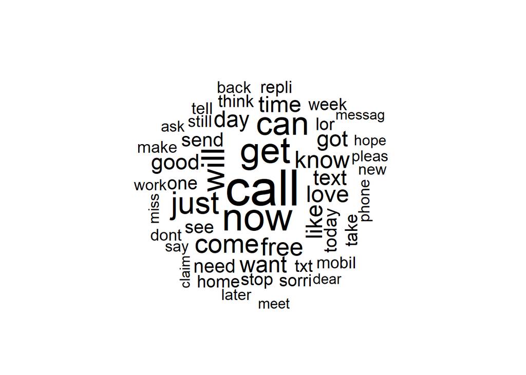

```r
library(wordcloud)
wordcloud(sms_corpus_clean, max.words = 50, random.order = FALSE)
```

Compare wordclouds between spam and ham.

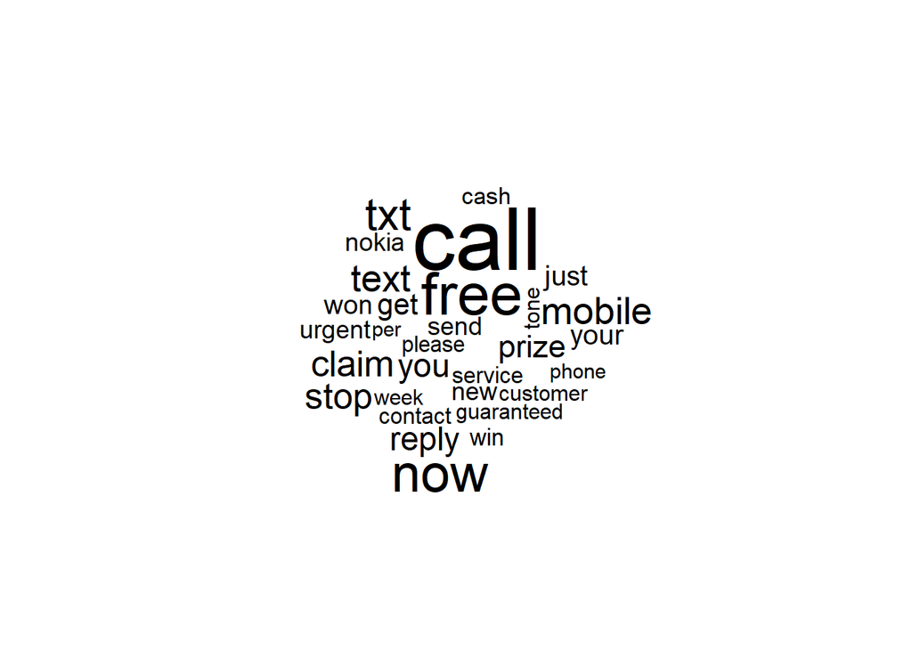

```r
spam <- subset(sms_raw, type == "spam")
ham <- subset(sms_raw, type == "ham")
wordcloud(spam$text, max.words = 30)
```

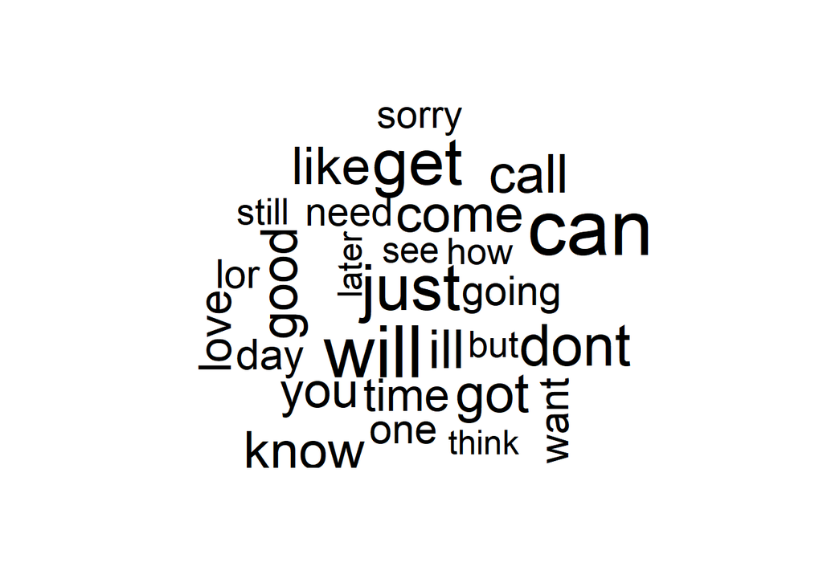

```r
wordcloud(ham$text, max.words = 30)
```

# 6 Preparation for Naive Bayes

Remove words from the matrix that appear less than 5 times.

```r
library(quanteda)
sms_freq_words <- findFreqTerms(sms_dtm_train, 5)
str(sms_freq_words)
```

```
##  chr [1:1134] "â£wk" "â\200¦" "â\200“" "abiola" "abl" "abt" "accept" ...
```

```r
sms_dtm_freq_train <- sms_dtm_train[ , sms_freq_words]
sms_dtm_freq_test <- sms_dtm_test[ , sms_freq_words]
```

```r
convert_counts <- function(x) {
  x <- ifelse(x > 0, "Yes", "No")
}
```

This replaces values greater than 0 with yes, and values not greater than 0 with no. Let’s apply it to our data.

```r
sms_train <- apply(sms_dtm_freq_train, MARGIN = 2, convert_counts)

sms_test <- apply(sms_dtm_freq_test, MARGIN = 2, convert_counts)
```

The resulting matrixes will be character type, with cells indicating “yes” or “no” if the word represented by the column appears in the message represented by the row.

# 7 Train Model on the Data.

Use the e1071 package to impliment the Naive Bayes algorithm on the data, and predict whether a message is likely to be spam or ham.

```r
library(e1071)
```

```r
sms_classifier <- naiveBayes(sms_train, sms_train_labels)
```

# 8 Predict and Evaluate the Model.

```r
sms_test_pred <- predict(sms_classifier, sms_test, laplace=T)
```

Evaluate the predition with the actual data using a crosstable from the gmodels package.

```r
library(gmodels)
CrossTable(sms_test_pred, sms_test_labels, prop.chisq = FALSE, prop.t = FALSE, dnn = c('predicted', 'actual'))
```

```
##
##
##    Cell Contents
## |-------------------------|
## |                       N |
## |           N / Row Total |
## |           N / Col Total |
## |-------------------------|
##
##
## Total Observations in Table:  1379
##
##
##              | actual
##    predicted |       ham |      spam | Row Total |
## -------------|-----------|-----------|-----------|
##          ham |      1192 |        20 |      1212 |
##              |     0.983 |     0.017 |     0.879 |
##              |     0.994 |     0.111 |           |
## -------------|-----------|-----------|-----------|
##         spam |         7 |       160 |       167 |
##              |     0.042 |     0.958 |     0.121 |
##              |     0.006 |     0.889 |           |
## -------------|-----------|-----------|-----------|
## Column Total |      1199 |       180 |      1379 |
##              |     0.869 |     0.131 |           |
## -------------|-----------|-----------|-----------|
##
##
```

We can also use the ‘caret’ package to evaluate the the prediction performance on the test set.

```r
library(caret)
confusionMatrix(sms_test_pred, sms_test_labels)
```

```
## Confusion Matrix and Statistics
##
##           Reference
## Prediction  ham spam
##       ham  1192   20
##       spam    7  160
##
##                Accuracy : 0.9804
##                  95% CI : (0.9716, 0.9871)
##     No Information Rate : 0.8695
##     P-Value [Acc > NIR] : < 2e-16
##
##                   Kappa : 0.911
##
##  Mcnemar's Test P-Value : 0.02092
##
##             Sensitivity : 0.9942
##             Specificity : 0.8889
##          Pos Pred Value : 0.9835
##          Neg Pred Value : 0.9581
##              Prevalence : 0.8695
##          Detection Rate : 0.8644
##    Detection Prevalence : 0.8789
##       Balanced Accuracy : 0.9415
##
##        'Positive' Class : ham
##
```